# WEEK 7: WRITING FUNCTIONS

## Monday, February 20th – NO CLASS!

I **highly** recommend you…

- Work through PA 7
- Read through and begin thinking about Lab 7

## Wednesday, February 22nd

Today we will…

- Mini lecture on text material
  - Function Basics
  - Environments & Scope
  - Lab 7 Preview
- Work time:
  - PA 7: Functions
  - Lab 7: Functions & Fish
  - Challenge 7: Incorporating Multiple Inputs

## Why write functions?

- Functions allow you to automate common tasks
- We’ve been using functions since Day 1
- Did you ever find yourself copy-pasting an analysis and changing small parts?

**Writing your OWN functions has 3 big advantages over copy-and-paste:**

1. Your code is easier to read
2. To change your analysis, simply change the function
3. No more mistakes from copy-paste

# Function Basics

## Function Syntax

[figure not shown]

## A (very) simple function

```r
add_two <- function(x) {

  x + 2

}
```

Let’s call the function!

```r
add_two(5)
```

```
[1] 7
```

## Naming functions – `add_two <-`

The **name** of the function is chosen by the author.

```r
add_two <- function(x) {

  x + 2

}
```

**A word of caution:** Function names have no inherent meaning.

```r
add_three <- function(x) {

  x + 7

}
```

What did you expect?

```r
add_three(5)
```

```
[1] 12
```

## Function Arguments

The **argument(s)** of the function are chosen by the author.

- `(x)`
- Optional arguments
- Required arguments

```r
add_two <- function(x) {

  x + 2

}
```

- arguments are temporary variables with general names
- `x`, `y`, `z` – vectors
- `df` – dataframe
- `i`, `j` – indices

We can supply a default argument value – `something =`

```r
add_something <- function(x, something = 2) {

  return(x + something)

}
```

`something` defaults to 2

```r
add_something(x = 5)
```

```
[1] 7
```

```r
add_something(x = 5, something = 6)
```

```
[1] 11
```

If you **do not** supply a default value, the argument is **required**: – `something`

```r
add_something <- function(x, something) {

  x + something

}

add_something(x = 2)
```

```
Error in add_something(x = 2): argument "something" is missing, with no default
```

## Function `{ body }`

The **body** of the function is where the action happens.

```r
add_two <- function(x) {

  x + 2

}
```

## `return()`

Your function will “give back” whatever would normally “print out”.

```r
add_two <- function(x) {

  x + 2

}
```

```r
7 + 2
```

```
[1] 9
```

```r
add_two(7)
```

```
[1] 9
```

You can be explicit (and clearer) by using `return()`

```r
add_two <- function(x) {

  return(x + 2)

}
```

## Input validation

- `stopifnot()`
- `if() + stop()`
- Multiple validations

```r
add_something <- function(x, something) {

  stopifnot(is.numeric(x))

  x + something

}

add_something(x = "statistics", something = 5)
```

```
Error in add_something(x = "statistics", something = 5): is.numeric(x) is not TRUE
```

```r
add_something <- function(x, something) {

  if(!is.numeric(x)){
    stop("Please provide a numeric input for the x argument.")
  }

  x + something

}

add_something(x = "statistics", something = 5)
```

```
Error in add_something(x = "statistics", something = 5): Please provide a numeric input for the x argument.
```

Recall DeMorgan’s law!

```r
add_something <- function(x, something) {

  if(!is.numeric(x) | !is.numeric(something)){
    stop("Please provide a numeric inputs for both arguments.")
  }

  x + something

}

add_something(x = 2, something = "R")
```

```
Error in add_something(x = 2, something = "R"): Please provide a numeric inputs for both arguments.
```

## Multiple Conditions

# Environments & Scope

## Environments

- The top right pane of your RStudio shows you **environment**.
- This is the “current state” of the objects you’ve created.

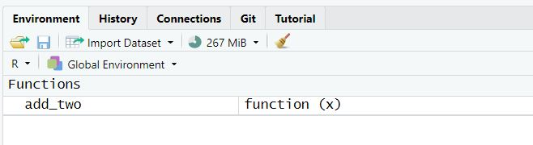

- The code inside the function executes in the **function environment**.
- It does not change your **global environment**.

## Searching…

```r
add_two <- function() {

  x + 2

}

add_two()
```

```
Error in add_two(): object 'x' not found
```

```r
x <- 10

add_two()
```

```
[1] 12
```

## Function Objects

Objects you make in the function don’t affect “real life”.

```r
add_two <- function(x) {

  my_result <- x + 2

  my_result

}
```

Let’s assign the variable `my_result` a value in the global environment (outside the function).

```r
my_result <- 2000
```

Inside the function, the global `my_result` variable is ignored.

```r
add_two(5)
```

```
[1] 7
```

But the global `my_result` variable still exists.

```r
my_result
```

```
[1] 2000
```

## Name Masking

## Debugging Strategies

## Lab 7 & Challenge 7

[Lab 7: Functions & Fish](https://earobinson95.github.io/stat331-calpoly/lab-assignments/lab7/lab7-functions-and-fish.html)

[Challenge 7: Incorporating Multiple Inputs](https://earobinson95.github.io/stat331-calpoly/lab-assignments/lab7/challenge7-functions-and-fish.html)

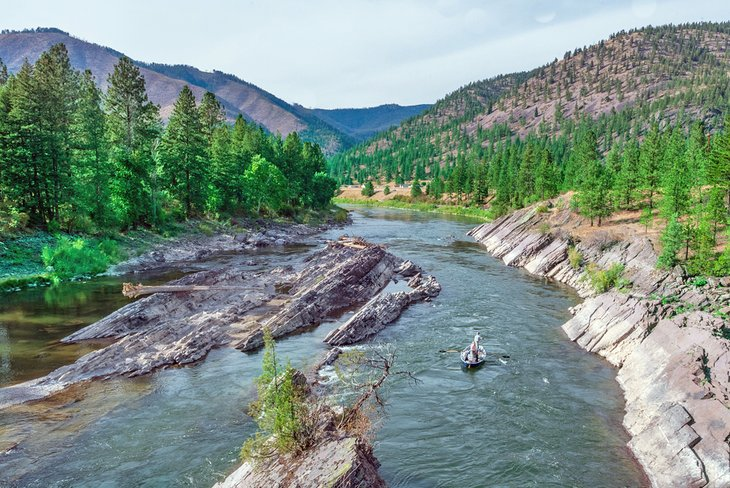

## Standardizing Between 0 and 1

```r
std_to_01 <- function(var) {
  stopifnot(is.numeric(var))

  num <- var - min(var, na.rm = TRUE)
  denom <- max(var, na.rm = TRUE) - min(var, na.rm = TRUE)

  num / denom
}
```

Could our function be more efficient?

## Ugh. Still copy + pasting!

```r
penguins |>
  mutate(bill_length_mm    = std_to_01(bill_length_mm),
         bill_depth_mm     = std_to_01(bill_depth_mm),
         flipper_length_mm = std_to_01(flipper_length_mm),
         body_mass_g       = std_to_01(body_mass_g)
  )
```

Recall `across()`!

```r
penguins |>
  mutate(across(.cols = bill_length_mm:body_mass_g,
                ~ std_to_01(.x)
                )
  )
```

## New option: Variables as Arguments!

```r
std_column_01 <- function(data, variable) {

  stopifnot(is.data.frame(data),
            is.numeric(variable)
            )

  data <- data |>
    mutate(variable = std_to_01(variable))

  data

}
```

**Note**

Notice how I relied on the existing function `std_to_01()` inside the new function, for clarity!

But it didn’t work…

```r
std_column_01(penguins, body_mass_g)
```

[output not shown]

## Tidy evaluation

Functions that use **unquoted** variable names as arguments are called *nonstandard evaluation* or *tidy evaluation*.

**Tidy**:

```r
penguins |>
  pull(body_mass_g)
```

```r
penguins$body_mass_g
```

**Untidy**:

```r
penguins[, "body_mass_g"]
```

```r
penguins[["body_mass_g"]]
```

## Solution 1 🤷

- Just don’t use tidy evaluations in your functions
- Harder to read / use, but safe

```r
std_column_01 <- function(data, variable) {

  stopifnot(is.data.frame(data),
            is.character(variable))

  data[[variable]] <- std_to_01(data[[variable]])

  data
}

std_column_01(penguins, "bill_length_mm")
```

## Solution 2 – Embrace Injection `library(rlang)`

In February 2020 `rlang` introduced the “injection” `{{ }}` operator to simplify writing functions around tidyverse pipelines.

[figure not shown]

With the `{{ }}` operator you can inject the name of data-variables (i.e. columns from the data frames) into function arguments!

**Warning**

This only works for `select()` type functions, that use a literal (tidy) name of the variable to subset the data.

## Recall Our Broken Function

```r
std_column_01 <- function(data, variable) {

  data <- data |>
    mutate(
      variable = std_to_01(variable)
    )

  data

}

std_column_01(penguins, body_mass_g)
```

```
Error in `mutate()`:
! Problem while computing `variable = std_to_01(variable)`.
Caused by error in `stopifnot()`:
! object 'body_mass_g' not found
```

- The problem here is that `mutate()` defuses the R code it was supplied.
- Instead we want it to see `body_mass_g = standardize(body_mass_g)`.

This is why we need injection!

## {{ variable }}

```r
std_column_01 <- function(data, variable) {

  stopifnot(is.data.frame(data))

  data <- data
    mutate({{ variable }} = std_to_01( {{ variable }})
           )
  data
}
```

```
Error: <text>:6:27: unexpected '='
5:   data <- data
6:     mutate({{ variable }} =
                             ^
```

**Danger**

Oh no! What happened?

The left hand side of `=` is also diffused!

## The “Walrus Operator” `:=`

The “walrus operator” `:=` is an alias of `=`.

You can use it to supply names, e.g. a := b is equivalent to a = b.

```r
std_column_01 <- function(data, variable) {

  stopifnot(is.data.frame(data))

  data <- data |>
    mutate({{ variable }} := std_to_01( {{ variable }})
           )
  data

}
```

## Don’t forget about `across()`

What if I want to modify multiple columns?

```r
std_column_01 <- function(data, variables) {

  stopifnot(is.data.frame(data))

  data <- data |>
    mutate(across(.cols = {{ variables }},
                  ~ std_to_01(.x)
                  )
           )

  data

}
```

```r
std_column_01(penguins, bill_length_mm:body_mass_g)
```

# Missing Data are important!

## Assumptions when removing missing data

**Without inspection:**

> Observations are “missing **completely** at random”

**With information about the “missingness”:**

> Observations are “missing at random”

Look for patterns!

## Missing data – Example

**If** fish length measurements are *missing at random*, conditional on month, year, and river section,

**then** the distributions of lengths will be similar for fish of the same month, year, and river section.

## Scaling Variables

**Why Scale?**

- (More) difficult to compare
- (More) difficult to model

**Why not Scale?**

- Difficult to interpret

## Interesting reads

[Article on How Building Functions with Variable Names has Changed Over the Years](https://www.bryanshalloway.com/2020/06/25/using-across-to-build-functions-with-dplyr-with-notes-on-legacy-approaches/)

[**rlang** Article on Data Masking](https://rlang.r-lib.org/reference/topic-data-mask.html)

## To do…

- **Final Project Group Contract**
  - Due Wednesday 2/22 at 11:59pm
- **PA 7: Functions**
  - Due Wednesday 2/22 at 11:59pm
- **Lab 7: Functions and Fish**
  - Due Friday 2/24 at 11:59pm
- **Challenge 7: Incorporating Multiple Inputs**
  - Due Saturday 2/25 at 11:59pm
- Read **Chapter 8: Functional Programming**
  - Check-in 8.1 due Monday 2/27 at 8am